# Iron Man’s Guide to Discrete Distributions

Marieth Coetzer

12/26/2022

## Binomial Distribution

**X represents the number of successes among N trials**

Iron Man throws at punch at Captain America 50 times. He has a 0.35 chance at landing a punch. The most probable number of hits he’s going to land is around 17.

n = 50 p = 0.35

X = 17

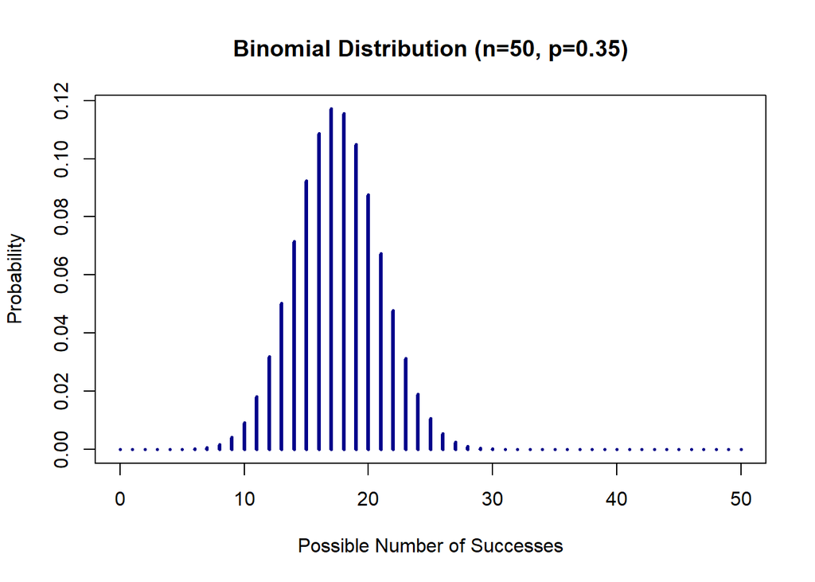

```r
possible_number_of_successes <- 0:50

distribution <- dbinom(possible_number_of_successes,size=50,prob=.35)

plot(possible_number_of_successes,distribution,
     type='h',
     main='Binomial Distribution (n=50, p=0.35)',
     ylab='Probability',
     xlab ='Possible Number of Successes',
     lwd=3, col = 'dark blue'  )
```

## Geometric Distribution

**X represents the number of trails needed until the first success**

Iron Man throws at punch at Captain America 50 times. He has a 0.35 chance at landing a punch. He will probably land his first hit the 1st or 2nd time.

p = 0.35

X = 1 or 2

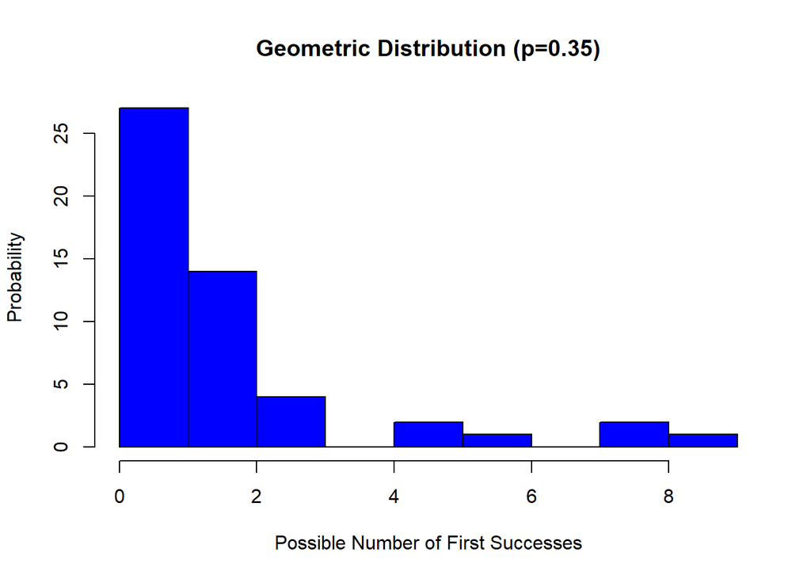

```r
possible_number_of_successes <- 0:50

distribution <- rgeom(possible_number_of_successes, prob=.35)

hist(distribution, col = "Blue",
     main='Geometric Distribution (p=0.35)',
     ylab='Probability',
     xlab ='Possible Number of First Successes',)
```

## Negative Binomial Distribution

**X represents the number of trails needed until r successes occur**

Iron Man throws at punch at Captain America 50 times. He has a 0.35 chance at landing a punch. It takes 10 hits for Captain America to slow down.

p = 0.35 n = 50 r = 10

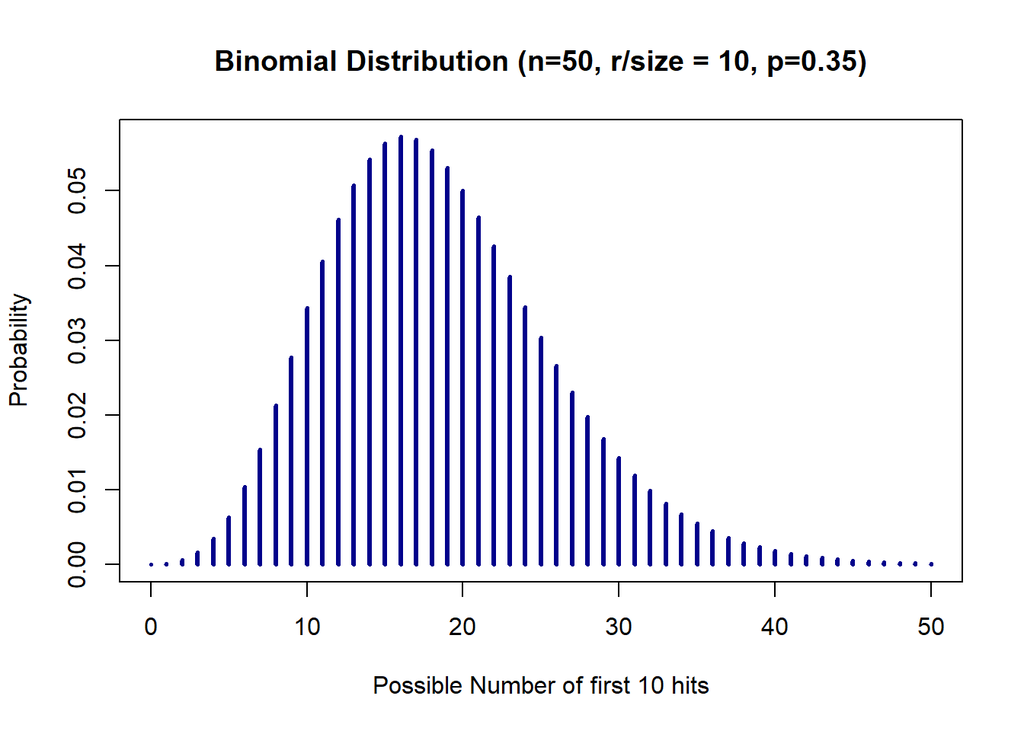

```r
possible_number_of_successes <- 0:50

distribution <- dnbinom(possible_number_of_successes, size = 10, prob=.35)

plot(possible_number_of_successes,distribution,
     type='h',
     main='Binomial Distribution (n=50, r/size = 10, p=0.35)',
     ylab='Probability',
     xlab ='Possible Number of first 10 hits',
     lwd=3, col = 'dark blue'  )
```

## Hypergeometric Distribution

**X represents the number of items among the n selected that comes from the r group.**

Iron Man has managed land a punch on Captain America 50 times. 15 of the punches were on the face, 35 of the punches were on the torso.

Given that 10 punches are randomly drawn and analyzed at random, what is the probability that 5 of those punches are on the face?

N = 50 K = 15 n = 10 k = 5 (this is the outcome we’re interested in finding the probability of)

There is a decent probability, but a higher probability that 3 of the punches are to the face.

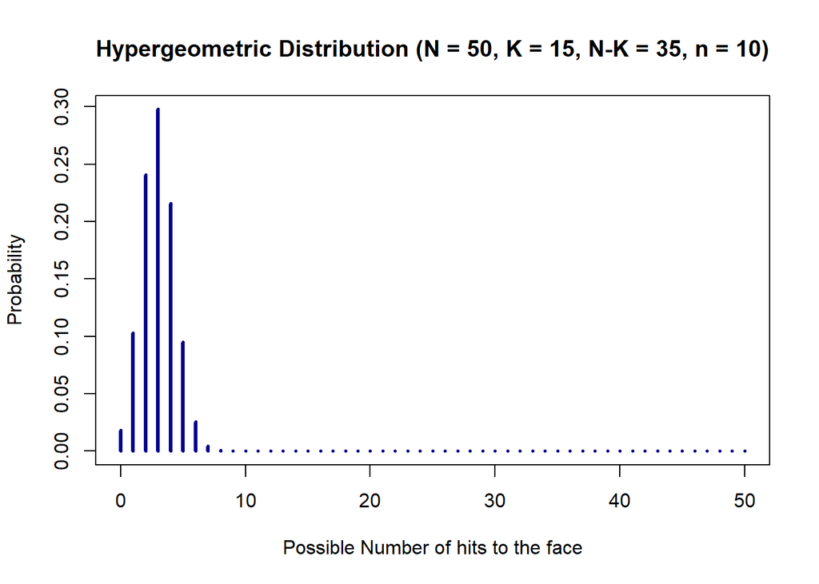

```r
possible_number_of_successes <- 0:50

distribution <- dhyper(possible_number_of_successes, 15,35,10)



plot(possible_number_of_successes,distribution,
     type='h',
     main='Hypergeometric Distribution (N = 50, K = 15, N-K = 35, n = 10)',
     ylab='Probability',
     xlab ='Possible Number of hits to the face',
     lwd=3, col = 'dark blue'  )
```

## Poisson Distribution

**X represents the number of events that occur in time, area, etc.**

Iron Man now puts together a summary based on many sparring matches. On average, in every sparring match he lands 20 punches in every sparring match.

mean = 20

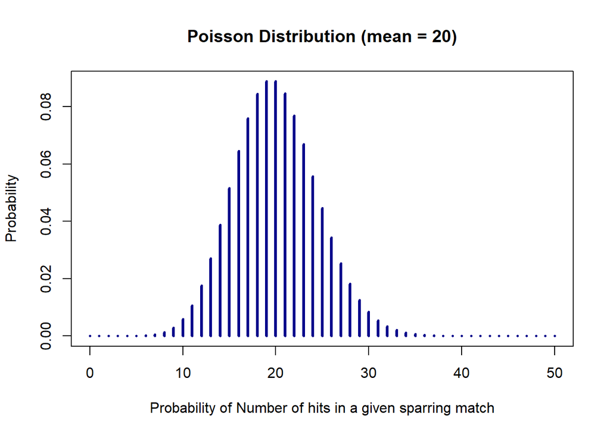

```r
possible_number_of_successes <- 0:50

distribution <- dpois(possible_number_of_successes, 20)



plot(possible_number_of_successes,distribution,
     type='h',
     main='Poisson Distribution (mean = 20)',
     ylab='Probability',
     xlab ='Probability of Number of hits in a given sparring match',
     lwd=3, col = 'dark blue'  )
```